# A Deep Dive into Ford GoBike System Data

## Preliminary Wrangling

> This dataset includes information about individual rides made in a bike-sharing system covering the greater San Francisco Bay area in December 2019.

```python
# import all packages and set plots to be embedded inline
import numpy as np
import pandas as pd
import matplotlib.pyplot as plt
import seaborn as sb
import geopy.distance
import os

%matplotlib inline
```

```python
df = pd.read_csv("201912-baywheels-tripdata.csv")
```

```python
df.shape
```

```
(150102, 14)
```

```python
df.head()
```

|  | duration_sec | start_time | end_time | start_station_id | start_station_name | start_station_latitude | start_station_longitude | end_station_id | end_station_name | end_station_latitude | end_station_longitude | bike_id | user_type | rental_access_method |
| --- | --- | --- | --- | --- | --- | --- | --- | --- | --- | --- | --- | --- | --- | --- |
| 0 | 66600 | 2019-12-31 14:28:50.2860 | 2020-01-01 08:58:51.2500 | 364.0 | China Basin St at 3rd St | 37.772000 | -122.389970 | 349.0 | Howard St at Mary St | 37.781010 | -122.405666 | 12085 | Customer | NaN |
| 1 | 36526 | 2019-12-31 21:52:47.7620 | 2020-01-01 08:01:33.9320 | 38.0 | The Embarcadero at Pier 38 | 37.782926 | -122.387921 | 410.0 | Illinois St at Cesar Chavez St | 37.750200 | -122.386567 | 9477 | Customer | NaN |
| 2 | 8164 | 2019-12-31 23:50:04.8770 | 2020-01-01 02:06:09.4140 | 14.0 | Clay St at Battery St | 37.795001 | -122.399970 | 6.0 | The Embarcadero at Sansome St | 37.804770 | -122.403234 | 10420 | Customer | NaN |
| 3 | 8163 | 2019-12-31 23:49:21.4000 | 2020-01-01 02:05:24.6670 | 14.0 | Clay St at Battery St | 37.795001 | -122.399970 | 6.0 | The Embarcadero at Sansome St | 37.804770 | -122.403234 | 2065 | Customer | NaN |
| 4 | 6847 | 2019-12-31 22:51:05.6850 | 2020-01-01 00:45:13.4860 | 3.0 | Powell St BART Station (Market St at 4th St) | 37.786375 | -122.404904 | 363.0 | Salesforce Transit Center (Natoma St at 2nd St) | 37.787492 | -122.398285 | 10219 | Customer | NaN |

```python
df.isnull().sum()
```

```
duration_sec                    0
start_time                      0
end_time                        0
start_station_id            21019
start_station_name          21015
start_station_latitude          0
start_station_longitude         0
end_station_id              21347
end_station_name            21345
end_station_latitude            0
end_station_longitude           0
bike_id                         0
user_type                       0
rental_access_method       122421
dtype: int64
```

```python
#It seems that the rental_access method is missed in the majority of data, so we w'll remove it
df.drop(columns=["rental_access_method"], inplace=True)

#We have enough points, so we can drop the null values from this dataset.
df.dropna(inplace=True)
df.reset_index(drop=True, inplace=True)
print(df.shape)
```

```
(125634, 13)
```

```python
print(df.info())
```

```
<class 'pandas.core.frame.DataFrame'>
RangeIndex: 125634 entries, 0 to 125633
Data columns (total 13 columns):
duration_sec               125634 non-null int64
start_time                 125634 non-null object
end_time                   125634 non-null object
start_station_id           125634 non-null float64
start_station_name         125634 non-null object
start_station_latitude     125634 non-null float64
start_station_longitude    125634 non-null float64
end_station_id             125634 non-null float64
end_station_name           125634 non-null object
end_station_latitude       125634 non-null float64
end_station_longitude      125634 non-null float64
bike_id                    125634 non-null int64
user_type                  125634 non-null object
dtypes: float64(6), int64(2), object(5)
memory usage: 12.5+ MB
None
```

```python
#It seems that we need to clean change some columns data types
df["start_time"] = pd.to_datetime(df["start_time"])
df["end_time"] = pd.to_datetime(df["end_time"])

df["start_station_id"] = df["start_station_id"].astype(int).astype(str)
df["end_station_id"] = df["end_station_id"].astype(int).astype(str)
df["bike_id"] = df["bike_id"].astype(str)

user_types = ['Subscriber', 'Customer']
df["user_type"] = df["user_type"].astype("category")

print(df.info())
```

```
<class 'pandas.core.frame.DataFrame'>
RangeIndex: 125634 entries, 0 to 125633
Data columns (total 13 columns):
duration_sec               125634 non-null int64
start_time                 125634 non-null datetime64[ns]
end_time                   125634 non-null datetime64[ns]
start_station_id           125634 non-null object
start_station_name         125634 non-null object
start_station_latitude     125634 non-null float64
start_station_longitude    125634 non-null float64
end_station_id             125634 non-null object
end_station_name           125634 non-null object
end_station_latitude       125634 non-null float64
end_station_longitude      125634 non-null float64
bike_id                    125634 non-null object
user_type                  125634 non-null category
dtypes: category(1), datetime64[ns](2), float64(4), int64(1), object(5)
memory usage: 11.6+ MB
None
```

### What is the structure of your dataset?

> Our dataset consists of the Bikesharing data for December 2019 and it has **150,102 rows** and **14 columns** Each trip is anonymized and includes:
> - Trip Duration (seconds)
> - Start Time and Date
> - End Time and Date
> - Start Station ID
> - Start Station Name
> - Start Station Latitude
> - Start Station Longitude
> - End Station ID
> - End Station Name
> - End Station Latitude
> - End Station Longitude
> - Bike ID
> - User Type (Subscriber or Customer – “Subscriber” = Member or “Customer” = Casual)
> - Bike Share for all trip

### What is/are the main feature(s) of interest in your dataset?

> My main feature of interest is the trip duration and we'll look into it and its relationship with other features as well

### What features in the dataset do you think will help support your investigation into your feature(s) of interest?

> I think week day , the hour, which we can get from the start_time column, the start and end locations as well

## Univariate Exploration

> In this section, investigate distributions of individual variables. If you see unusual points or outliers, take a deeper look to clean things up and prepare yourself to look at relationships between variables.

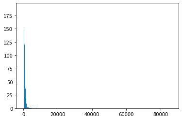

```python
#We'll plot the histogram of the trip duration in seconds
bins = np.arange(df["duration_sec"].min(), df["duration_sec"].max()+1,1)
plt.hist(data=df, x="duration_sec", bins=bins)
plt.show();
```

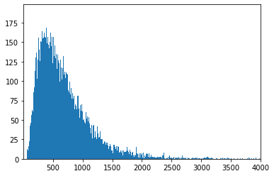

```python
#Let's adjust the limits of x-axis to zoom in and get a better understanding of the histogram of the trip duration:
bins = np.arange(df["duration_sec"].min(), df["duration_sec"].max()+1,1)
plt.hist(data=df, x="duration_sec", bins=bins)
plt.xlim([6,4000])
plt.show();
```

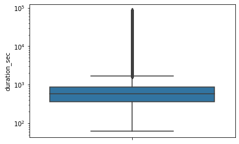

```python
#Let's check the box-plot of the duration in seconds
sb.boxplot(data=df, y="duration_sec")
plt.yscale("log")
plt.show();
```

We can see that the boxplot support the previous histogram and it shows the outliers's range as well in an effective way.

**Let's check the hour of the day when the trip started:**

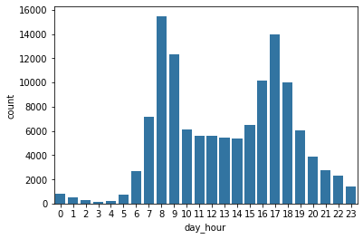

```python
#Let's have a column for the start-hour
df["day_hour"] = df["start_time"].dt.hour

#Let's plot the count plot for the hour
sb.countplot(data= df, x="day_hour", color=sb.color_palette()[0])
plt.show();
```

It seems that seems that there are two peaks in the day. They are 8 and 17. Nice!

Also, we can see that the curve is skewed to the left at the early hours of the day before 6:00 AM.

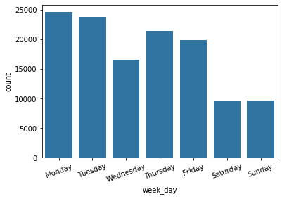

```python
#Let's have a column for the week-day
df["week_day"] = df["start_time"].dt.weekday_name
df["week_day"] = pd.Categorical(df['week_day'], categories=['Monday','Tuesday','Wednesday','Thursday','Friday','Saturday', 'Sunday'], ordered=True)

#Let's plot the count plot for the wekk day
sb.countplot(data= df, x="week_day", color=sb.color_palette()[0])
plt.xticks(rotation=20)
plt.show();
```

Let's get the distance traveled during the trip to have another numerical variable!

```python
def get_distance(row):
    '''
    This function is to get the distance between two coordinate points in meters.
    '''
    coords_1 = (row["start_station_latitude"], row["start_station_longitude"])
    coords_2 = (row["end_station_latitude"], row["end_station_longitude"])
    return geopy.distance.geodesic(coords_1, coords_2).km*1000
```

```python
df["traveled_distance"] = df.apply(get_distance, axis=1)
```

[figure not shown]

```python
#plotting the histogram of distance travelled in meters
plt.hist(data=df, x="traveled_distance", bins=50)
plt.xlim([0,5000])
plt.show();
```

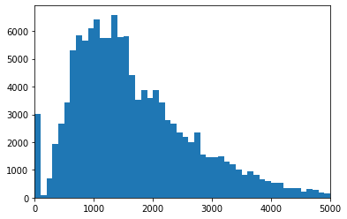

```python
#plotting the histogram of distance travelled in meters for trips lower than 5000 meters
df2 = df.loc[df["traveled_distance"]<5000]
plt.hist(data=df2, x="traveled_distance", bins=50)
plt.xlim([0,5000])
plt.show();
```

- It seems that trips less than 5 KM are skewed to the right
- There are more trips below the mean than longer-distance trips

### Discuss the distribution(s) of your variable(s) of interest. Were there any unusual points? Did you need to perform any transformations?

**Trip Duration**

**Day Hours**

> - It looks that the plot is bi-modal as there are two peaks of the day-hours.
> - It's skewed to the left at the early hours before 6:00 AM.

**Weekdays**

**Travelled Distance in meters**

### Of the features you investigated, were there any unusual distributions? Did you perform any operations on the data to tidy, adjust, or change the form of the data? If so, why did you do this?

**Trip Duration**

> Becasue we have too many points with low distribution on the right, we used the Log scale which gave us a better BoxPlot and we set the limits for the histogram to show a better histogram.

**Travelled Distance in meters**

> Histogram of trips < 5 km are skewed to the right which indicates that more trips are below the mean and the median of the sample

## Bivariate Exploration

> In this section, investigate relationships between pairs of variables in your data. Make sure the variables that you cover here have been introduced in some fashion in the previous section (univariate exploration).

Now, We'll check the relationship between the trip duration over different weekdays.

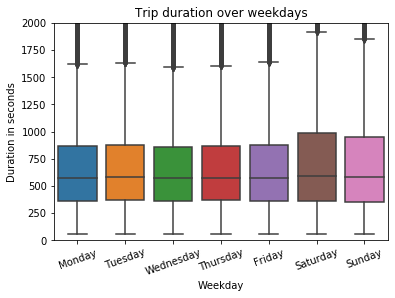

```python
#We'll check the trip duration in seconds over the week days
sb.boxplot(data=df,x = 'week_day' , y = 'duration_sec' )
plt.title('Trip duration over weekdays')
plt.xlabel('Weekday')
plt.ylabel('Duration in seconds')
plt.xticks(rotation=20)
plt.ylim([0,2000])
plt.show()
```

We can see that trips have most of the trips under 2000 seconds over all the week days!

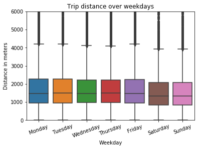

```python
#We'll check the trip distance in meters over the week days
sb.boxplot(data = df , x = 'week_day' , y = 'traveled_distance')
plt.title('Trip distance over weekdays')
plt.xlabel('Weekday')
plt.ylabel('Distance in meters')
plt.ylim([0,6000]) #As I'm more interested in trips below 1 KM
plt.xticks(rotation=20)
plt.show()
```

We can see that most of the trips are more 200 meters long all over the week.

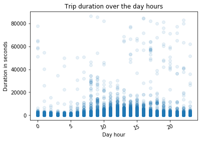

```python
#We'll check the trip duration in seconds over the day hours
plt.scatter(data = df , x = 'day_hour' , y = 'duration_sec' , alpha = 0.1 )
plt.title('Trip duration over the day hours')
plt.xlabel('Day hour')
plt.ylabel('Duration in seconds')
plt.xticks(rotation=20)
plt.show()
```

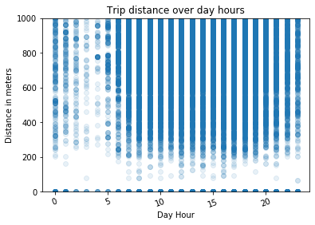

```python
#We'll check the trip distance in meters over the day hours
plt.scatter(data = df , x = 'day_hour' , y = 'traveled_distance' , alpha = 0.1 )
plt.title('Trip distance over day hours')
plt.xlabel('Day Hour')
plt.ylabel('Distance in meters')
plt.ylim([0,1000]) #As I'm more interested in trips below 1 KM
plt.xticks(rotation=20)
plt.show()
```

### Did you observe any interesting relationships between the other features (not the main feature(s) of interest)?

> The behavior is almost consistent over the week days.

## Multivariate Exploration

> Create plots of three or more variables to investigate your data even further. Make sure that your investigations are justified, and follow from your work in the previous sections.

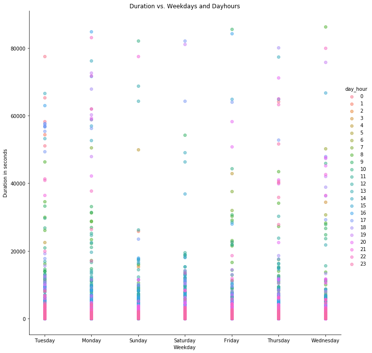

```python
#Let's look into the duration of the trip while considering both the weekday and the day-hour variables
grid = sb.FacetGrid(data =  df, hue = 'day_hour', height = 10)
grid.map(plt.scatter, 'week_day','duration_sec', alpha = 0.5)
plt.title('Duration vs. Weekdays and Dayhours')
plt.xlabel('Weekday')
plt.ylabel('Duration in seconds')
grid.add_legend()
plt.show();
```

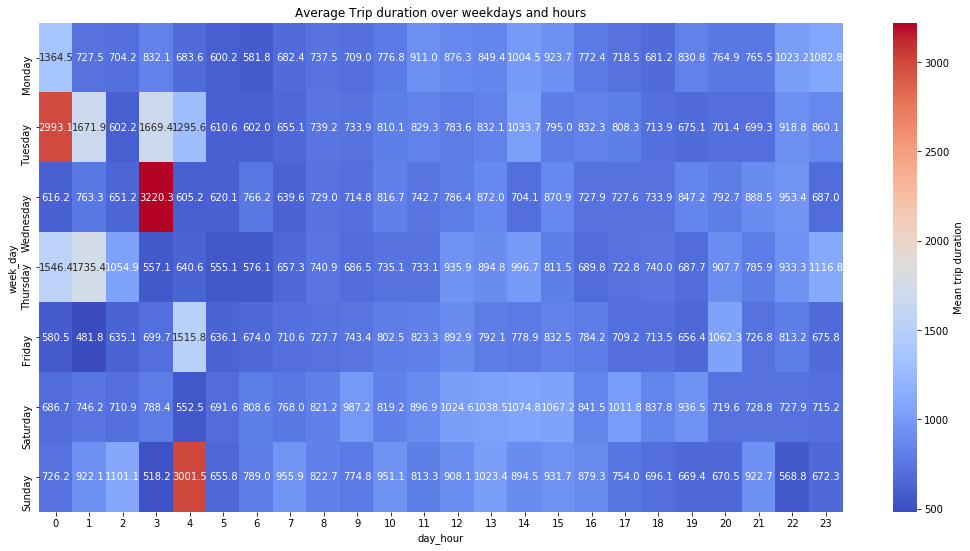

```python
#Let's plot the Heat map of the trip duration over different days and hours
pivot = df.pivot_table(values="duration_sec", index="week_day", columns="day_hour")
plt.figure(figsize=(18,9))
sb.heatmap(pivot, annot=True, fmt="0.1f", cbar_kws={"label":"Mean trip duration"}, cmap="coolwarm")
plt.title("Average Trip duration over weekdays and hours")
bottom, top = plt.gca().get_ylim()
plt.gca().set_ylim(bottom + 0.5, top - 0.5)
plt.show();
```

```python
dataset = df.groupby(["start_station_latitude","start_station_longitude"])["start_station_latitude","start_station_longitude"].count()
dataset.rename(columns={"start_station_latitude":"number_of_trips"}, inplace=True)
dataset.drop(columns=["start_station_longitude"], inplace=True)
dataset.reset_index(inplace=True, drop=False)
dataset.head()
```

|  | start_station_latitude | start_station_longitude | number_of_trips |
| --- | --- | --- | --- |
| 0 | 37.309014 | -121.900011 | 17 |
| 1 | 37.311284 | -121.896325 | 17 |
| 2 | 37.315158 | -121.897833 | 9 |
| 3 | 37.316736 | -121.910005 | 19 |
| 4 | 37.317298 | -121.884995 | 9 |

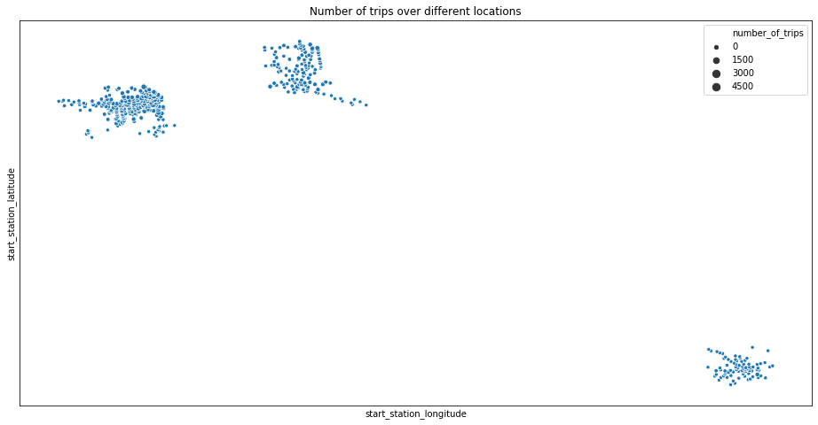

```python
plt.figure(figsize=(16,8))
sb.scatterplot(x="start_station_longitude", y="start_station_latitude", size="number_of_trips", data=dataset)
plt.title("Number of trips over different locations")
plt.xticks([])
plt.yticks([])
plt.legend()
plt.show();
```

### Talk about some of the relationships you observed in this part of the investigation. Were there features that strengthened each other in terms of looking at your feature(s) of interest?

> We can see more shade of violent rides which reflects trips very late from 20:00 to 1:00 at the zone of short trips.

### Were there any interesting or surprising interactions between features?

> It assured the previous results from the bivariate analysis.

> At the end of your report, make sure that you export the notebook as an html file from the `File > Download as... > HTML` menu. Make sure you keep track of where the exported file goes, so you can put it in the same folder as this notebook for project submission. Also, make sure you remove all of the quote-formatted guide notes like this one before you finish your report!